# Lab Report

Ye Li

7/24/2019

## Introduction

We are using this document to practice a reproducible workflow that help documenting the data analysis process for sharing on GitHub, and eventually could be shared on open repositories like Zenodo.

*Your first task*: Replace the author name Ye Li with your name on the top section.

Now, we will plot a simple calibration curve to show how it works.

## Data source

Fe<sup>3+</sup> + SCN<sup>-</sup> <-> FeSCN<sup>2+</sup>

(Thanks to Prof. Steve Wathen providing the dataset from a real chemistry lab.)

## Plot calibration curve

Now, we will plot the imported data as a calibration curve

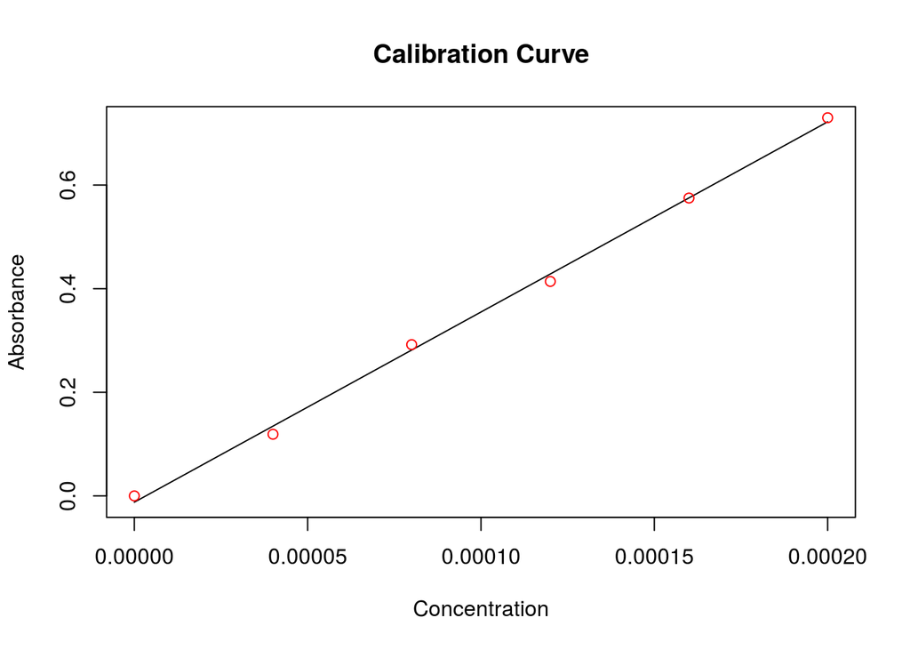

[output not shown]